# Harmonization Problems

Pedro Salguero

08 noviembre, 2022

## Dataset information

The reference data set is Calabria. The other data set that will be merge into the reference are Humanitas, Monza, Spain. We are working with a total of 4 databases.

## Variable Venn Diagram - All variables

Venn diagram between all variables between all databases.

### Venn Diagram

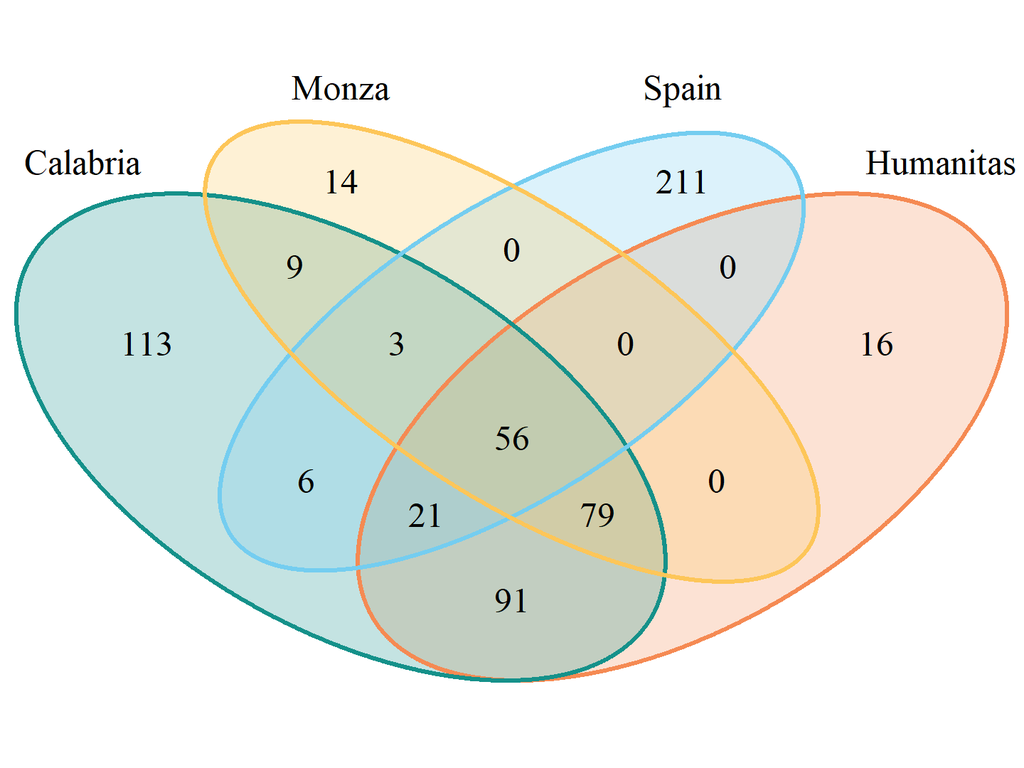

| . |
| --- |

### Upset plot

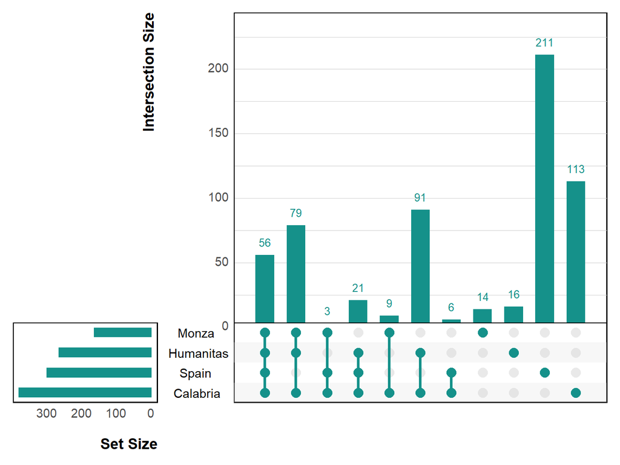

| . |
| --- |

## Variable Venn Diagram - Commond Variables

As the first database will be selected as the reference, a second Venn diagram is shown to illustrate how many variables could be keept in the merge databases.

### Venn Diagram

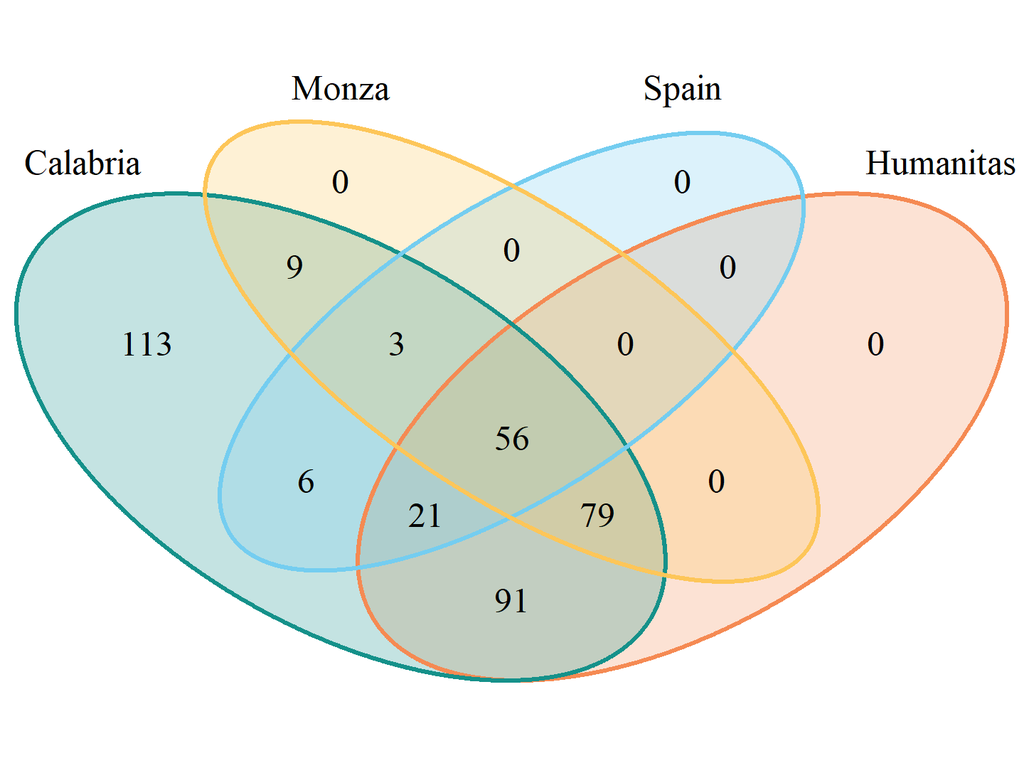

| . |
| --- |

### Upset plot

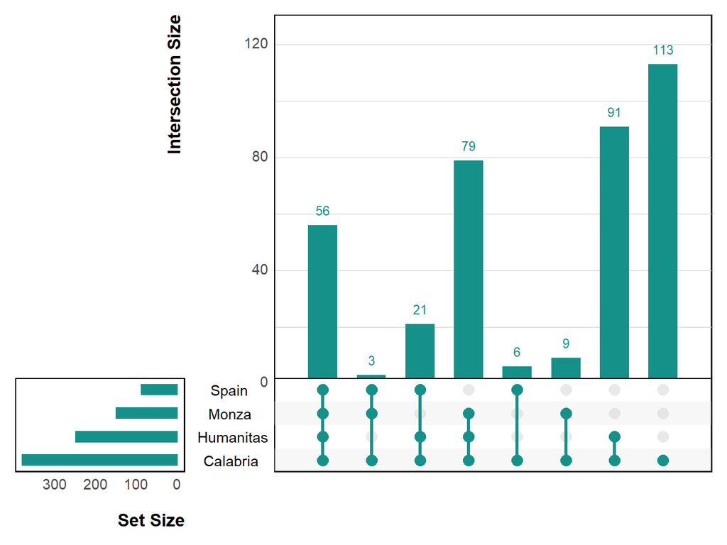

| . |
| --- |

## Class problems between template and databases

The next variables have not could updated to the specified class in the template file. We recommend to update those variable by hand before running the Harmonization Script, and try it again.

### Calabria

| Variable | Class | Found | Fixed |
| --- | --- | --- | --- |
| hosttim | Date | character | FALSE |

### Humanitas

| Info |
| --- |
| No variables with problems. |

### Monza

| Info |
| --- |
| No variables with problems. |

### Spain

| Info |
| --- |
| No variables with problems. |

## Class fixed between template and databases

The next variables have been updated to the correct class. However, due to automatic process, may be some problems in the conversion that could be probably be detected in posteriors steps.

### Calabria

| Variable | Class | Found | Fixed |
| --- | --- | --- | --- |
| redcap_repeat_instance | numeric | integer | TRUE |
| dsstdat | Date | character | TRUE |
| sitename | factor | character | TRUE |
| egestage_rptestcd | numeric | integer | TRUE |
| cestdat | Date | character | TRUE |
| hostdat | Date | character | TRUE |
| siteid_transfer | factor | character | TRUE |
| hostdat_transfer | Date | character | TRUE |
| erendat | Date | character | TRUE |
| hr_vsorres | numeric | integer | TRUE |
| rr_vsorres | numeric | integer | TRUE |
| sysbp_vsorres | numeric | integer | TRUE |
| admission_diabp_vsorres | numeric | integer | TRUE |
| oxy_vsorres | numeric | integer | TRUE |
| height_vsorres | numeric | integer | TRUE |
| daily_dsstdat | Date | character | TRUE |
| daily_hr_vsorres | numeric | integer | TRUE |
| daily_rr_vsorres | numeric | integer | TRUE |
| systolic_vsorres | numeric | integer | TRUE |
| diastolic_vsorres | numeric | integer | TRUE |
| daily_gcs_vsorres | numeric | integer | TRUE |
| daily_pco2_lborres | numeric | integer | TRUE |
| daily_baseex_lborres | numeric | character | TRUE |
| rass_vsorres | numeric | integer | TRUE |
| daily_meanart_vsorres | numeric | integer | TRUE |
| daily_urine_lborres | numeric | integer | TRUE |
| daily_lbdat | Date | character | TRUE |
| daily_alt_lborres | numeric | integer | TRUE |
| daily_ast_lborres | numeric | integer | TRUE |
| daily_sodium_lborres | numeric | integer | TRUE |
| daily_ldh_lborres | numeric | integer | TRUE |
| daily_crekin_lborres | numeric | integer | TRUE |
| oxygen_cmdur | numeric | integer | TRUE |
| noninvaisve_prdur | numeric | integer | TRUE |
| invasive_prdur | numeric | integer | TRUE |
| prone_prdur | numeric | integer | TRUE |
| inotrop_prdur | numeric | integer | TRUE |
| hodur | numeric | integer | TRUE |
| icu_hostdat | Date | character | TRUE |
| hoendat | Date | character | TRUE |
| inotrope_cmstdat | Date | character | TRUE |
| inotrope_cmendat | Date | character | TRUE |
| mbdat | Date | character | TRUE |
| lopin_antiviral_cmdat | Date | character | TRUE |
| lopin_antiviral_cmdur | numeric | integer | TRUE |
| remde_antiviral_cmdat | Date | character | TRUE |
| remde_antiviral_cmdur | numeric | integer | TRUE |
| chlor_antiviral_cmdat | Date | character | TRUE |
| chlor_antiviral_cmdur | numeric | integer | TRUE |
| antiviral_cmdat | Date | character | TRUE |
| antiviral_cmdur | numeric | integer | TRUE |
| antibiotic_cmdat_1 | Date | character | TRUE |
| antibiotic_cmdur_1 | numeric | integer | TRUE |
| antibiotic_cmdat_2 | Date | character | TRUE |
| antibiotic_cmdur_2 | numeric | integer | TRUE |
| antibiotic_cmdat_3 | Date | character | TRUE |
| antibiotic_cmdur_3 | numeric | integer | TRUE |
| corticos_cmdat | Date | character | TRUE |
| corticos_cmdur | numeric | integer | TRUE |
| heparin_cmdat | Date | character | TRUE |
| heparin_cmdur | numeric | integer | TRUE |
| othertx_cmdat_1 | Date | character | TRUE |
| othertx_cmdur_1 | numeric | integer | TRUE |
| othertx_cmdur_2 | numeric | integer | TRUE |
| dsstdtc | Date | character | TRUE |
| siteid | factor | character | TRUE |

### Humanitas

| Variable | Class | Found | Fixed |
| --- | --- | --- | --- |
| sitename | factor | character | TRUE |
| country | factor | character | TRUE |
| ethnic___1 | factor | numeric | TRUE |
| ethnic___2 | factor | numeric | TRUE |
| ethnic___3 | factor | numeric | TRUE |
| ethnic___4 | factor | numeric | TRUE |
| ethnic___5 | factor | numeric | TRUE |
| ethnic___6 | factor | numeric | TRUE |
| ethnic___7 | factor | numeric | TRUE |
| ethnic___8 | factor | numeric | TRUE |
| ethnic___9 | factor | numeric | TRUE |
| ethnic___10 | factor | numeric | TRUE |
| healthwork_erterm | factor | character | TRUE |
| labwork_erterm | factor | character | TRUE |
| sex | factor | character | TRUE |
| age_estimateyearsu | factor | character | TRUE |
| pregyn_rptestcd | factor | character | TRUE |
| hoyn | factor | character | TRUE |
| temp_vsorresu | factor | character | TRUE |
| oxy_vsorresu | factor | character | TRUE |
| weight_vsorresu | factor | character | TRUE |
| fever_ceoccur_v2 | factor | character | TRUE |
| cough_ceoccur_v2_2 | factor | character | TRUE |
| cough_ceoccur_v2 | factor | character | TRUE |
| sorethroat_ceoccur_v2 | factor | character | TRUE |
| runnynose_ceoccur_v2 | factor | character | TRUE |
| wheeze_ceoccur_v2 | factor | character | TRUE |
| shortbreath_ceoccur_v2 | factor | character | TRUE |
| lowerchest_ceoccur_v2 | factor | character | TRUE |
| chestpain_ceoccur_v2 | factor | character | TRUE |

[output cut: 132 more lines]

### Monza

| Variable | Class | Found | Fixed |
| --- | --- | --- | --- |
| sitename | factor | character | TRUE |
| country | factor | character | TRUE |
| healthwork_erterm | factor | numeric | TRUE |
| sex | factor | numeric | TRUE |
| age_estimateyearsu | factor | character | TRUE |
| hoyn | factor | numeric | TRUE |
| temp_vsorresu | factor | character | TRUE |
| oxy_vsorresu | factor | numeric | TRUE |
| weight_vsorresu | factor | character | TRUE |
| fever_ceoccur_v2 | factor | numeric | TRUE |
| coughsput_ceoccur_v2 | factor | numeric | TRUE |
| coughhb_ceoccur_v2 | factor | numeric | TRUE |
| sorethroat_ceoccur_v2 | factor | numeric | TRUE |
| runnynose_ceoccur_v2 | factor | numeric | TRUE |
| shortbreath_ceoccur_v2 | factor | numeric | TRUE |
| lowerchest_ceoccur_v2 | factor | numeric | TRUE |
| chestpain_ceoccur_v2 | factor | numeric | TRUE |
| conjunct_ceoccur_v2 | factor | numeric | TRUE |
| lymp_ceoccur_v2 | factor | numeric | TRUE |
| headache_ceoccur_v2 | factor | numeric | TRUE |
| anosmia_ceoccur_v2 | factor | numeric | TRUE |
| ageusia_ceoccur_v2 | factor | numeric | TRUE |
| seizures_cecoccur_v2 | factor | numeric | TRUE |
| fatigue_ceoccur_v2 | factor | numeric | TRUE |
| confusion_ceoccur_v2 | factor | numeric | TRUE |
| myalgia_ceoccur_v2 | factor | numeric | TRUE |
| jointpain_ceoccur_v2 | factor | numeric | TRUE |
| inablewalk_ceoccur_v2 | factor | numeric | TRUE |
| abdopain_ceoccur_v2 | factor | numeric | TRUE |
| diarrhoea_ceoccur_v2 | factor | numeric | TRUE |

[output cut: 67 more lines]

### Spain

| Variable | Class | Found | Fixed |
| --- | --- | --- | --- |
| sitename | factor | character | TRUE |
| country | factor | character | TRUE |
| sex | factor | numeric | TRUE |
| fever_ceoccur_v2 | factor | numeric | TRUE |
| pre_othmed_cmoccur | factor | numeric | TRUE |
| chroniccard_mhyn | factor | numeric | TRUE |
| hypertension_mhyn | factor | numeric | TRUE |
| chronicpul_mhyn | factor | numeric | TRUE |
| asthma_mhyn | factor | numeric | TRUE |
| renal_mhyn | factor | numeric | TRUE |
| modliver_mhyn | factor | numeric | TRUE |
| chronicneu_mhyn | factor | numeric | TRUE |
| aidshiv_mhyn_2 | factor | numeric | TRUE |
| diabetes_mhyn_2 | factor | numeric | TRUE |
| daily_hb_lborresu | factor | character | TRUE |
| daily_wbc_lborresu | factor | character | TRUE |
| daily_lymp_lborresu | factor | character | TRUE |
| daily_neutro_lborresu | factor | character | TRUE |
| daily_plt_lborresu | factor | character | TRUE |
| daily_alt_lborresu | factor | character | TRUE |
| daily_ast_lborresu | factor | character | TRUE |
| daily_creat_lborresu | factor | character | TRUE |
| daily_procal_lborresu | factor | character | TRUE |
| daily_crp_lborresu | factor | character | TRUE |
| daily_ldh_lborresu | factor | character | TRUE |
| daily_ddimer_lborresu | factor | character | TRUE |
| daily_ferritin_lborresu | factor | character | TRUE |
| oxygen_cmoccur | factor | numeric | TRUE |
| oxygen_cmdur | numeric | difftime | TRUE |
| noninvasive_proccur | factor | numeric | TRUE |
| noninvaisve_prdur | numeric | difftime | TRUE |
| invasive_proccur | factor | numeric | TRUE |
| invasive_prdur | numeric | difftime | TRUE |
| pronevent_prtrt | factor | numeric | TRUE |
| icu_hoterm | factor | numeric | TRUE |
| hodur | numeric | difftime | TRUE |
| ards_ceterm | factor | numeric | TRUE |
| renalinjury_ceterm | factor | numeric | TRUE |
| liverdysfunction_ceterm | factor | numeric | TRUE |
| clinicalpneu_mborres | factor | numeric | TRUE |
| antiviral_cmtrt___2 | factor | numeric | TRUE |
| antiviral_cmtrt___7 | factor | numeric | TRUE |
| antiviral_cmtrt___4 | factor | numeric | TRUE |
| antiviral_cmtrt___8 | factor | numeric | TRUE |
| antiviral_cmtrt___6 | factor | numeric | TRUE |
| lopin_antiviral_cmdur | numeric | difftime | TRUE |
| chlor_antiviral_cmdur | numeric | difftime | TRUE |
| antibiotic_cmyn | factor | numeric | TRUE |
| antibiotic_cmdur_1 | numeric | difftime | TRUE |
| corticost_cmyn | factor | numeric | TRUE |
| corticos_cmdur | numeric | difftime | TRUE |
| heparint_cmyn | factor | numeric | TRUE |
| dsterm | factor | numeric | TRUE |

## Qualitative variable study

Next step of the pipeline will generate .xlsx files with an easy struture to update incongruencies in level/category names between each database and the reference one.

The structure is:

| VAR: var_name_ref / var_name | Category1, Category2, Category3… (reference database) |
| --- | --- |
| CAT1 |  |
| CAT2 |  |

CAT1 and CAT2 are related to the database are going to be merged. As At least of one of those categories have not been detected in the reference one, the user must specified the equivalence in reference categories. Also, if a new name is introduced, a new factor will be added to the reference. If the field is left empty, that category will be deleted and those samples will get a NA value.

Remember to fill the FILES before perform next Harmonization script.

### Calabria

| Info |
| --- |
| All variables have the correct categories. |

### Humanitas

| Variable | Description | Group |
| --- | --- | --- |
| sitename | Clinical centre name: | INDIVIDUAL_INFORMATION_VAR |
| ethnic___1 | Ethnic group (choice=Arab) | INDIVIDUAL_INFORMATION_VAR |
| ethnic___2 | Ethnic group (choice=Black) | INDIVIDUAL_INFORMATION_VAR |
| ethnic___3 | Ethnic group (choice=East Asian) | INDIVIDUAL_INFORMATION_VAR |
| ethnic___4 | Ethnic group (choice=South Asian) | INDIVIDUAL_INFORMATION_VAR |
| ethnic___5 | Ethnic group (choice=West Asian) | INDIVIDUAL_INFORMATION_VAR |
| ethnic___6 | Ethnic group (choice=Latin American) | INDIVIDUAL_INFORMATION_VAR |
| ethnic___7 | Ethnic group (choice=White) | INDIVIDUAL_INFORMATION_VAR |
| ethnic___8 | Ethnic group (choice=Aboriginal/First Nations) | INDIVIDUAL_INFORMATION_VAR |
| ethnic___9 | Ethnic group (choice=Other) | INDIVIDUAL_INFORMATION_VAR |
| ethnic___10 | Ethnic group (choice=N/A) | INDIVIDUAL_INFORMATION_VAR |
| smoking_mhyn | Smoking | COMORBIDITIES_RISKFACTORS_VAR |
| daily_noninvasive_prtype | Non-invasive ventilation - if YES: | DAY1_VAR |
| siteid | 7.4.1. If Transferred: Facility name | OUTCOME_VAR |

### Monza

| Variable | Description | Group |
| --- | --- | --- |
| sitename | Clinical centre name: | INDIVIDUAL_INFORMATION_VAR |
| healthwork_erterm | Employed as a healthcare worker? | INDIVIDUAL_INFORMATION_VAR |
| sex | Sex at Birth: | INDIVIDUAL_INFORMATION_VAR |
| hoyn | Was the patient admitted previously or transferred from any other facility during this illness episode? | INDIVIDUAL_INFORMATION_VAR |
| oxy_vsorresu | Oxygen saturation on: | SIGNS_HOSPITAL_ADMISSION_VAR |
| fever_ceoccur_v2 | History of fever | SYMPTOMS_HOSPITAL_ADMISSION_VAR |
| coughsput_ceoccur_v2 | 4a.2.1 Cough: with sputum production | SYMPTOMS_HOSPITAL_ADMISSION_VAR |
| coughhb_ceoccur_v2 | 4a.2.2 Cough: bloody sputum / haemoptysis | SYMPTOMS_HOSPITAL_ADMISSION_VAR |
| sorethroat_ceoccur_v2 | Sore throat | SYMPTOMS_HOSPITAL_ADMISSION_VAR |
| runnynose_ceoccur_v2 | Runny nose (Rhinorrhoea) | SYMPTOMS_HOSPITAL_ADMISSION_VAR |
| shortbreath_ceoccur_v2 | Shortness of breath (Dyspnea) | SYMPTOMS_HOSPITAL_ADMISSION_VAR |
| lowerchest_ceoccur_v2 | Lower chest wall indrawing | SYMPTOMS_HOSPITAL_ADMISSION_VAR |
| chestpain_ceoccur_v2 | Chest pain | SYMPTOMS_HOSPITAL_ADMISSION_VAR |
| conjunct_ceoccur_v2 | Conjunctivitis | SYMPTOMS_HOSPITAL_ADMISSION_VAR |
| lymp_ceoccur_v2 | Lymphadenopathy | SYMPTOMS_HOSPITAL_ADMISSION_VAR |
| headache_ceoccur_v2 | Headache | SYMPTOMS_HOSPITAL_ADMISSION_VAR |
| anosmia_ceoccur_v2 | Loss of smell (Anosmia) | SYMPTOMS_HOSPITAL_ADMISSION_VAR |
| ageusia_ceoccur_v2 | Loss of taste (Ageusia) | SYMPTOMS_HOSPITAL_ADMISSION_VAR |
| seizures_cecoccur_v2 | Seizures | SYMPTOMS_HOSPITAL_ADMISSION_VAR |
| fatigue_ceoccur_v2 | Fatigue / Malaise | SYMPTOMS_HOSPITAL_ADMISSION_VAR |
| confusion_ceoccur_v2 | Altered consciousness / confusion | SYMPTOMS_HOSPITAL_ADMISSION_VAR |
| myalgia_ceoccur_v2 | Muscle aches (Myalgia) | SYMPTOMS_HOSPITAL_ADMISSION_VAR |
| jointpain_ceoccur_v2 | Joint pain (Arthralgia) | SYMPTOMS_HOSPITAL_ADMISSION_VAR |
| inablewalk_ceoccur_v2 | Inability to walk | SYMPTOMS_HOSPITAL_ADMISSION_VAR |
| abdopain_ceoccur_v2 | Abdominal pain | SYMPTOMS_HOSPITAL_ADMISSION_VAR |
| diarrhoea_ceoccur_v2 | Diarrhoea | SYMPTOMS_HOSPITAL_ADMISSION_VAR |
| vomit_ceoccur_v2 | Vomiting / Nausea | SYMPTOMS_HOSPITAL_ADMISSION_VAR |
| rash_ceoccur_v2 | Skin rash | SYMPTOMS_HOSPITAL_ADMISSION_VAR |
| chroniccard_mhyn | Chronic cardiac disease (not hypertension) | COMORBIDITIES_RISKFACTORS_VAR |
| hypertension_mhyn | 140mmHg systolic or >90mmHg diastolic.>Hypertension | COMORBIDITIES_RISKFACTORS_VAR |
| chronicpul_mhyn | Chronic pulmonary disease (not asthma) | COMORBIDITIES_RISKFACTORS_VAR |
| asthma_mhyn | Asthma (physician diagnosed) | COMORBIDITIES_RISKFACTORS_VAR |
| renal_mhyn | Chronic kidney disease | COMORBIDITIES_RISKFACTORS_VAR |
| obesity_mhyn | Obesity (as defined by clinical staff) | COMORBIDITIES_RISKFACTORS_VAR |
| modliver_mhyn | Moderate or severe liver disease | COMORBIDITIES_RISKFACTORS_VAR |
| mildliv_mhyn | Mild liver disease | COMORBIDITIES_RISKFACTORS_VAR |
| chronicneu_mhyn | Chronic neurological disorder | COMORBIDITIES_RISKFACTORS_VAR |
| malignantneo_mhyn | 5 years ago with no evidence of ongoing disease. Do not include non-melanoma skin cancers. Do not include benign growths or dysplasia.>Malignant neoplasm | COMORBIDITIES_RISKFACTORS_VAR |
| chronhaemo_mhyn | Chronic hematologic disease | COMORBIDITIES_RISKFACTORS_VAR |
| aidshiv_mhyn_2 | AIDS / HIV | COMORBIDITIES_RISKFACTORS_VAR |
| diabetes_mhyn_2 | Diabetes Mellitus | COMORBIDITIES_RISKFACTORS_VAR |
| rheumatology_mhyr | Rheumatologic disorder | COMORBIDITIES_RISKFACTORS_VAR |
| dementia_mhyn | Dementia | COMORBIDITIES_RISKFACTORS_VAR |
| malnutrition_mhyn | Malnutrition | COMORBIDITIES_RISKFACTORS_VAR |
| smoking_mhyn | Smoking | COMORBIDITIES_RISKFACTORS_VAR |
| oxygen_cmoccur | Any Oxygen therapy? | TREATMENTS_VAR |
| noninvasive_proccur | Non-invasive ventilation? (Any) | TREATMENTS_VAR |
| pronevent_prtrt | Prone Positioning sometime? | TREATMENTS_VAR |
| tracheo_prtrt | Tracheostomy inserted sometime? | TREATMENTS_VAR |
| extracorp_prtrt | Extracorporeal support (ECMO)? | TREATMENTS_VAR |
| icu_hoterm | ICU or High Dependency Unit admission? | TREATMENTS_VAR |
| viralpneu_ceterm | Viral pneumonia/pneumonitis | COMPLICATIONS_VAR |
| ards_ceterm | Acute Respiratory Distress Syndrome | COMPLICATIONS_VAR |
| ardssev_ceterm | Acute Respiratory Distress Syndrome - if YES, specify: | COMPLICATIONS_VAR |
| ischaemia_ceterm | Cardiac ischemia | COMPLICATIONS_VAR |
| arrhythmia_ceterm | Cardiac arrhythmia | COMPLICATIONS_VAR |
| myocarditis_ceterm | Myocarditis/Pericarditis | COMPLICATIONS_VAR |
| endocarditis_ceterm | Endocarditis | COMPLICATIONS_VAR |
| heartfailure_ceterm | Congestive heart failure | COMPLICATIONS_VAR |
| seizure_ceterm | Seizure | COMPLICATIONS_VAR |
| stroke_ceterm | Stroke / Cerebrovascular accident | COMPLICATIONS_VAR |
| pulmemb_ceterm | Pulmonary embolism | COMPLICATIONS_VAR |
| renalinjury_ceterm | Acute renal injury / Acute renal failure | COMPLICATIONS_VAR |
| ceterm_clin_dx | Was patient clinically diagnoses with COVID-19? | DIAGNOSTIC_VAR |
| mbperf | Was pathogen testing done during this illness episode? | DIAGNOSTIC_VAR |
| xray_prperf_v2 | Chest X-Ray performed? | DIAGNOSTIC_VAR |
| ct_prperf | CT performed? | DIAGNOSTIC_VAR |
| dsterm | Outcome: | OUTCOME_VAR |

### Spain

| Variable | Description | Group |
| --- | --- | --- |
| sitename | Clinical centre name: | INDIVIDUAL_INFORMATION_VAR |
| sex | Sex at Birth: | INDIVIDUAL_INFORMATION_VAR |
| fever_ceoccur_v2 | History of fever | SYMPTOMS_HOSPITAL_ADMISSION_VAR |
| pre_othmed_cmoccur | Other targeted COVID-19 Medications | MEDICATION_PREADMISION_VAR |
| chroniccard_mhyn | Chronic cardiac disease (not hypertension) | COMORBIDITIES_RISKFACTORS_VAR |
| hypertension_mhyn | 140mmHg systolic or >90mmHg diastolic.>Hypertension | COMORBIDITIES_RISKFACTORS_VAR |
| chronicpul_mhyn | Chronic pulmonary disease (not asthma) | COMORBIDITIES_RISKFACTORS_VAR |
| asthma_mhyn | Asthma (physician diagnosed) | COMORBIDITIES_RISKFACTORS_VAR |
| renal_mhyn | Chronic kidney disease | COMORBIDITIES_RISKFACTORS_VAR |
| modliver_mhyn | Moderate or severe liver disease | COMORBIDITIES_RISKFACTORS_VAR |
| chronicneu_mhyn | Chronic neurological disorder | COMORBIDITIES_RISKFACTORS_VAR |
| aidshiv_mhyn_2 | AIDS / HIV | COMORBIDITIES_RISKFACTORS_VAR |
| diabetes_mhyn_2 | Diabetes Mellitus | COMORBIDITIES_RISKFACTORS_VAR |
| oxygen_cmoccur | Any Oxygen therapy? | TREATMENTS_VAR |
| noninvasive_proccur | Non-invasive ventilation? (Any) | TREATMENTS_VAR |
| invasive_proccur | Invasive ventilation? (Any) | TREATMENTS_VAR |
| pronevent_prtrt | Prone Positioning sometime? | TREATMENTS_VAR |
| icu_hoterm | ICU or High Dependency Unit admission? | TREATMENTS_VAR |
| ards_ceterm | Acute Respiratory Distress Syndrome | COMPLICATIONS_VAR |
| renalinjury_ceterm | Acute renal injury / Acute renal failure | COMPLICATIONS_VAR |
| liverdysfunction_ceterm | Liver dysfunction | COMPLICATIONS_VAR |
| clinicalpneu_mborres | Clinical pneumonia diagnosed? | DIAGNOSTIC_VAR |
| antiviral_cmtrt___2 | Antiviral or COVID-19 targeted agent - if YES, specify all agents: (choice=Lopinavir/Ritonvir) | MEDICATION_VAR |
| antiviral_cmtrt___7 | Antiviral or COVID-19 targeted agent - if YES, specify all agents: (choice=Remdesivir) | MEDICATION_VAR |
| antiviral_cmtrt___4 | Antiviral or COVID-19 targeted agent - if YES, specify all agents: (choice=Interferon beta) | MEDICATION_VAR |
| antiviral_cmtrt___8 | Antiviral or COVID-19 targeted agent - if YES, specify all agents: (choice=Chloroquine/hydroxychloroquine) | OTHER |
| antiviral_cmtrt___6 | Antiviral or COVID-19 targeted agent - if YES, specify all agents: (choice=Other) | MEDICATION_VAR |
| antibiotic_cmyn | Antibiotic? | MEDICATION_VAR |
| corticost_cmyn | Corticosteroid? | MEDICATION_VAR |
| heparint_cmyn | Heparin? | MEDICATION_VAR |
| dsterm | Outcome: | OUTCOME_VAR |

## Unit of measurement study

All units are correct between all databases.

## Save Process

Databases are saved in .RData and .xlsx format with their new colnames. Excel format does not save the same R class for each variable. We recommend to work with .RData files in case you want to do your own study.